# EDA_GroupG

2025-10-13

Importing our dataset into R Markdown:

```r
library(readr)

student_depression_dataset_CSV <- read_csv("student_depression_dataset_CSV.csv")
View(student_depression_dataset_CSV)
```

We found a data set that analyzes mental health trends and predictors among students, which we ended up naming to StudentDep. We reorganized the data so it has 70 cases and 17 variables. Our goal was to make sure that the variables was layed out properly and in a better fit so we could analyze.

```r
StudentDep <- student_depression_dataset_CSV[1:70, c("Gender", "Age", "City", "Profession", "Academic_Pressure", "Work_Pressure", "CGPA", "Study_Satisfaction", "Job_Satisfaction", "Sleep_Duration", "Dietary_Habits", "Degree", "Suicidal_Thoughts", "Work/Study_Hours", "Financial_Stress", "Family_History_of_Mental_Illness", "Depression")]
dim(StudentDep)
```

```
## [1] 70 17
```

```r
StudentDep
```

```
## # A tibble: 70 × 17
##    Gender   Age City          Profession Academic_Pressure Work_Pressure  CGPA
##    <chr>  <dbl> <chr>         <chr>                  <dbl>         <dbl> <dbl>
##  1 Male      33 Visakhapatnam Student                    5             0  8.97
##  2 Female    24 Bangalore     Student                    2             0  5.9
##  3 Male      31 Srinagar      Student                    3             0  7.03
##  4 Female    28 Varanasi      Student                    3             0  5.59
##  5 Female    25 Jaipur        Student                    4             0  8.13
##  6 Male      29 Pune          Student                    2             0  5.7
##  7 Male      30 Thane         Student                    3             0  9.54
##  8 Female    30 Chennai       Student                    2             0  8.04
##  9 Male      28 Nagpur        Student                    3             0  9.79
## 10 Male      31 Nashik        Student                    2             0  8.38
## # ℹ 60 more rows
## # ℹ 10 more variables: Study_Satisfaction <dbl>, Job_Satisfaction <dbl>,
## #   Sleep_Duration <chr>, Dietary_Habits <chr>, Degree <chr>,
## #   Suicidal_Thoughts <chr>, `Work/Study_Hours` <dbl>, Financial_Stress <dbl>,
## #   Family_History_of_Mental_Illness <chr>, Depression <dbl>
```

What we did here is converted the categorical variables into numerical form, such as 1 for males and 0 for females. As well as for Dietary Habits and Sleep Duration, they were changed into numeric factors.

```r
# Making sure to change Gender to binary so its Males = 1, and Female = 0
StudentDep$Gender <- ifelse(StudentDep$Gender == "Male", 1, 0)

# Also doing this for Family History of Mental Illness converting, binary (Yes = 1, No = 0)
StudentDep$Family_History_of_Mental_Illness <- ifelse(StudentDep$Family_History_of_Mental_Illness == "Yes", 1, 0)

# Converting ordinal variables for Dietary Habits and Sleep Duration
StudentDep$Dietary_Habits <- as.numeric(factor(StudentDep$Dietary_Habits,
                                                  levels = c("Unhealthy", "Moderate", "Healthy"),
                                                  ordered = TRUE))
StudentDep$Sleep_Duration <- as.numeric(factor(StudentDep$Sleep_Duration,
                                                  levels = c("'Less than 5 hours'", "'5-6 hours'", "'7-8 hours'", "'More than 8 hours'"),
                                                  ordered = TRUE))

# Converting Depression, for binary levels. Yes = 1 and No = 0
#StudentDep$Depression <- ifelse(StudentDep$Depression == "Yes", 1, 0)

str(StudentDep)
```

```
## tibble [70 × 17] (S3: tbl_df/tbl/data.frame)
##  $ Gender                          : num [1:70] 1 0 1 0 0 1 1 0 1 1 ...
##  $ Age                             : num [1:70] 33 24 31 28 25 29 30 30 28 31 ...
##  $ City                            : chr [1:70] "Visakhapatnam" "Bangalore" "Srinagar" "Varanasi" ...
##  $ Profession                      : chr [1:70] "Student" "Student" "Student" "Student" ...
##  $ Academic_Pressure               : num [1:70] 5 2 3 3 4 2 3 2 3 2 ...
##  $ Work_Pressure                   : num [1:70] 0 0 0 0 0 0 0 0 0 0 ...
##  $ CGPA                            : num [1:70] 8.97 5.9 7.03 5.59 8.13 5.7 9.54 8.04 9.79 8.38 ...
##  $ Study_Satisfaction              : num [1:70] 2 5 5 2 3 3 4 4 1 3 ...
##  $ Job_Satisfaction                : num [1:70] 0 0 0 0 0 0 0 0 0 0 ...
##  $ Sleep_Duration                  : num [1:70] 2 2 1 3 2 1 3 1 3 1 ...
##  $ Dietary_Habits                  : num [1:70] 3 2 3 2 2 3 3 1 2 2 ...
##  $ Degree                          : chr [1:70] "B.Pharm" "BSc" "BA" "BCA" ...
##  $ Suicidal_Thoughts               : chr [1:70] "Yes" "No" "No" "Yes" ...
##  $ Work/Study_Hours                : num [1:70] 3 3 9 4 1 4 1 0 12 2 ...
##  $ Financial_Stress                : num [1:70] 1 2 1 5 1 1 2 1 3 5 ...
##  $ Family_History_of_Mental_Illness: num [1:70] 0 1 1 1 0 0 0 1 0 0 ...
##  $ Depression                      : num [1:70] 1 0 0 1 0 0 0 0 1 1 ...
```

```r
summary(StudentDep)
```

```
##      Gender            Age            City            Profession
##  Min.   :0.0000   Min.   :18.00   Length:70          Length:70
##  1st Qu.:0.0000   1st Qu.:21.00   Class :character   Class :character
##  Median :1.0000   Median :24.00   Mode  :character   Mode  :character
##  Mean   :0.6286   Mean   :24.87
##  3rd Qu.:1.0000   3rd Qu.:28.75
##  Max.   :1.0000   Max.   :34.00
##  Academic_Pressure Work_Pressure      CGPA       Study_Satisfaction
##  Min.   :1.000     Min.   :0     Min.   :5.240   Min.   :1.000
##  1st Qu.:2.000     1st Qu.:0     1st Qu.:6.250   1st Qu.:2.000
##  Median :3.000     Median :0     Median :7.250   Median :3.000
##  Mean   :2.929     Mean   :0     Mean   :7.528   Mean   :2.986
##  3rd Qu.:4.000     3rd Qu.:0     3rd Qu.:8.588   3rd Qu.:4.000
##  Max.   :5.000     Max.   :0     Max.   :9.930   Max.   :5.000
##  Job_Satisfaction Sleep_Duration  Dietary_Habits     Degree
##  Min.   :0        Min.   :1.000   Min.   :1.000   Length:70
##  1st Qu.:0        1st Qu.:1.000   1st Qu.:1.000   Class :character
##  Median :0        Median :2.000   Median :2.000   Mode  :character
##  Mean   :0        Mean   :2.314   Mean   :1.986
##  3rd Qu.:0        3rd Qu.:3.000   3rd Qu.:3.000
##  Max.   :0        Max.   :4.000   Max.   :3.000
##  Suicidal_Thoughts  Work/Study_Hours Financial_Stress
##  Length:70          Min.   : 0.000   Min.   :1
##  Class :character   1st Qu.: 2.250   1st Qu.:2
##  Mode  :character   Median : 7.000   Median :3
##                     Mean   : 6.457   Mean   :3
##                     3rd Qu.:10.000   3rd Qu.:4
##                     Max.   :12.000   Max.   :5
##  Family_History_of_Mental_Illness   Depression
##  Min.   :0.0000                   Min.   :0.0
##  1st Qu.:0.0000                   1st Qu.:0.0
##  Median :1.0000                   Median :0.5
##  Mean   :0.5429                   Mean   :0.5
##  3rd Qu.:1.0000                   3rd Qu.:1.0
##  Max.   :1.0000                   Max.   :1.0
```

```r
dim(StudentDep)
```

```
## [1] 70 17
```

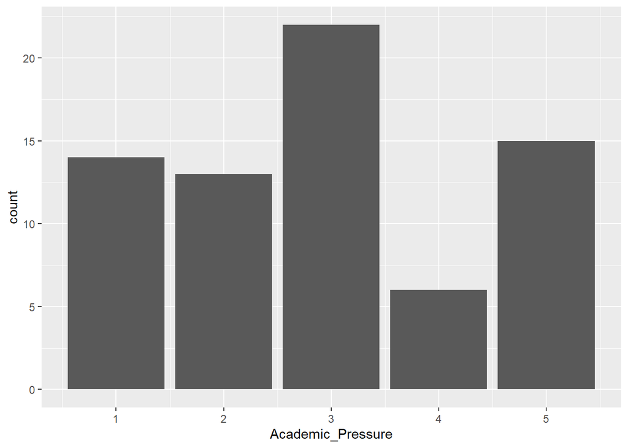

```r
ggplot(StudentDep) + geom_bar(aes(x = Academic_Pressure))
```